# Regression Models Course Project

Palani

Saturday, May 07, 2016

## Objective

Given the `Motor Trend`, data set of a collection of `cars`, interested in exploring the relationship between a set of variables and miles per gallon (MPG) (outcome). And particularly interested in the following two objectives:

- “Is an `automatic` or `manual` transmission better for MPG”
- “Quantify the `MPG difference` between automatic and manual transmissions”

## Introduction

The data was extracted from the 1974 Motor Trend US magazine, and comprises `fuel consumption` and 10 aspects of automobile design and performance for 32 automobiles (1973-74 models).The aspects of automobile design and performance are `Number of cyclinders` ,`Displacement`,`Gross horsepower`,`Rear axle ratio`,`Weight (lb/1000)`,`1/4 mile time`,`V/S`,`Transmission (0 = automatic, 1 = manual)`, `Number of forward gears`,`Number of carburetors`

```
##    mpg cyl disp  hp drat    wt  qsec vs am gear carb
## 1 21.0   6  160 110 3.90 2.620 16.46  0  1    4    4
## 2 21.0   6  160 110 3.90 2.875 17.02  0  1    4    4
## 3 22.8   4  108  93 3.85 2.320 18.61  1  1    4    1
## 4 21.4   6  258 110 3.08 3.215 19.44  1  0    3    1
## 5 18.7   8  360 175 3.15 3.440 17.02  0  0    3    2
## 6 18.1   6  225 105 2.76 3.460 20.22  1  0    3    1
```

```
## [1] 32 11
```

## Executive Summary

This project explores the relationship between miles-per-gallon (MPG) and other variables in the mtcars data set. In particular, the analysis attempts to determine whether an automatic or manual transmission is better for MPG, and quantifies the MPG difference.

Exploratory section reveals univariate and bivariate analysis , which gives pre information before attempting to model.

The Analysis section of this document focuses on inference with a simple linear regression model and a multiple regression model. Both models support the conclusion that the cars in this study with manual transmissions have on average significantly higher MPG’s than cars with automatic transmissions.

This conclusion holds whether we consider the relationship between MPG and transmission type alone or transmission type together with 2 other predictors: wt / weight; and qsec / 1/4 mile time.

In the simple model, the mean MPG difference is 7.245 MPG; the average MPG for cars with automatic transmissions is 17.147 MPG. In the multiple regression model, the MPG difference is 2.9358 MPG at the mean weight and qsec.

### Exploratory Data Analysis

#### Univariate Analysis.

**Unique Values**

Based on unique values on each columns , confirming `cyl`,`vs`,`am`,`gear`,`carb` are `categorical` values

```
##  mpg  cyl disp   hp drat   wt qsec   vs   am gear carb
##   25    3   27   22   22   29   30    2    2    3    6
```

**Density plot for `continous` variables.**

Slight skewness present in `mpg` and `hp`

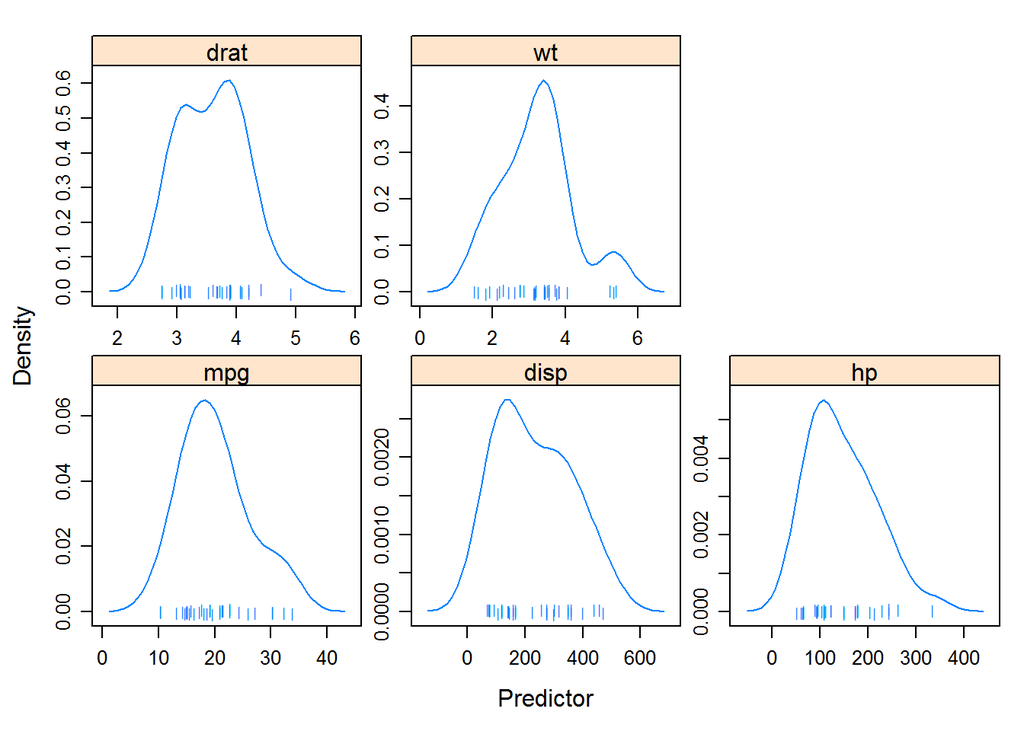

**Skewness Metrics**

All the numeric variables are almost normal .And there is no significant skewness present in the continous variables.

```
##       mpg      disp        hp      drat        wt      qsec
## 0.6106550 0.3816570 0.7260237 0.2659039 0.4231465 0.3690453
```

**category variable distribution**

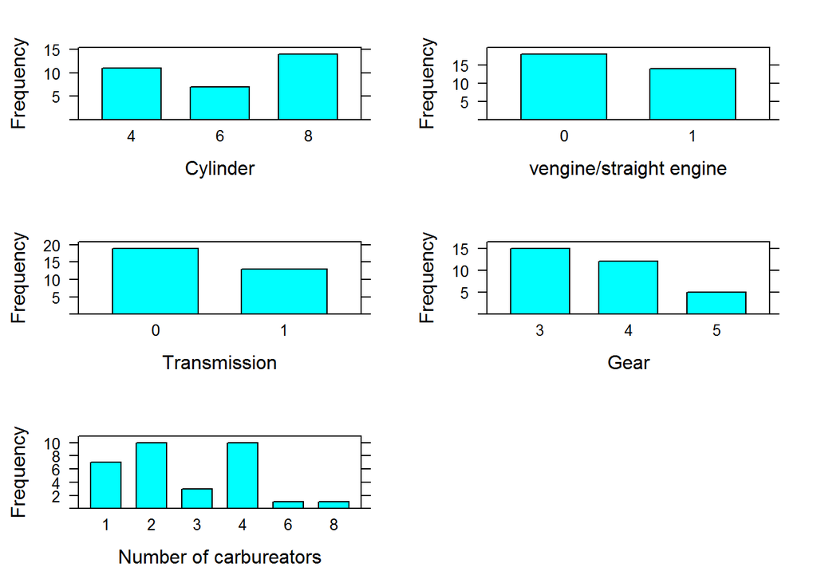

#### Bi variate analysis

**MPG vs categoric variables**

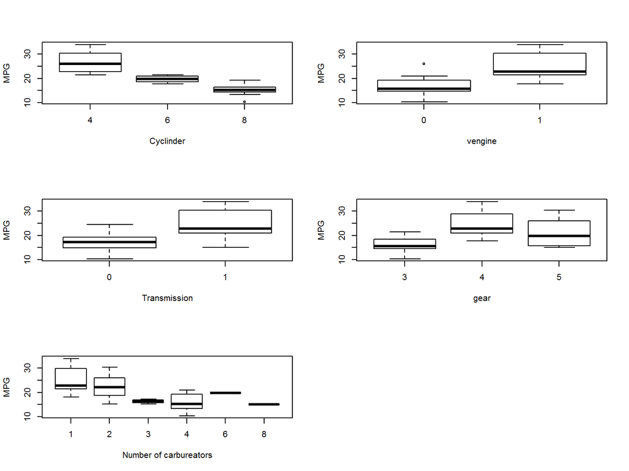

**corrplot for continous variables**

There is a strong linear relationship between response `mpg` and `predictor` variables.  
And there is cause of concern for predictor variables are correlated with each other, this violates the independent predictor variable assumption of linear regression.

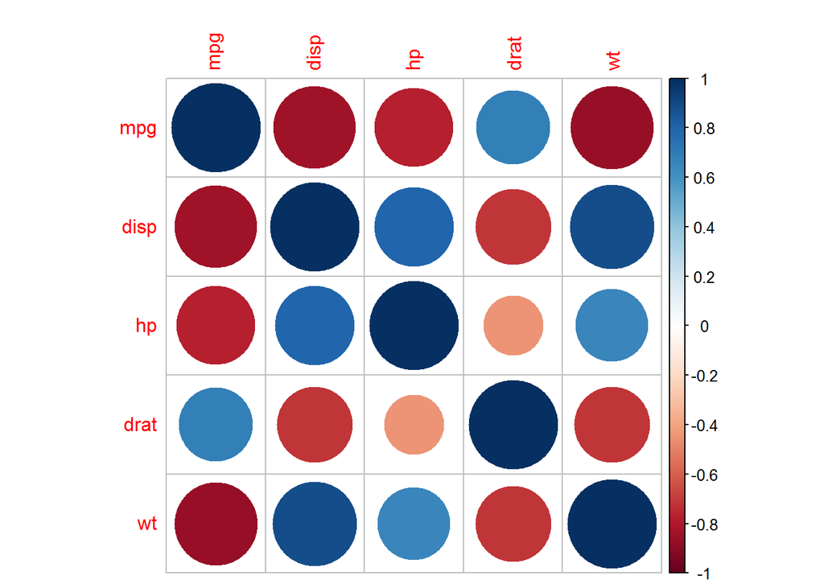

**Loess smooth curve** The lowess smoother shows a non-parametric estimate of the fitted regression line at each predictor value. This smooth curve is pre intimation of whether linear regression line is possible or not. And there is interesting fact is that all the continous variables have slightly curvilinear relationship with response `mpg`.

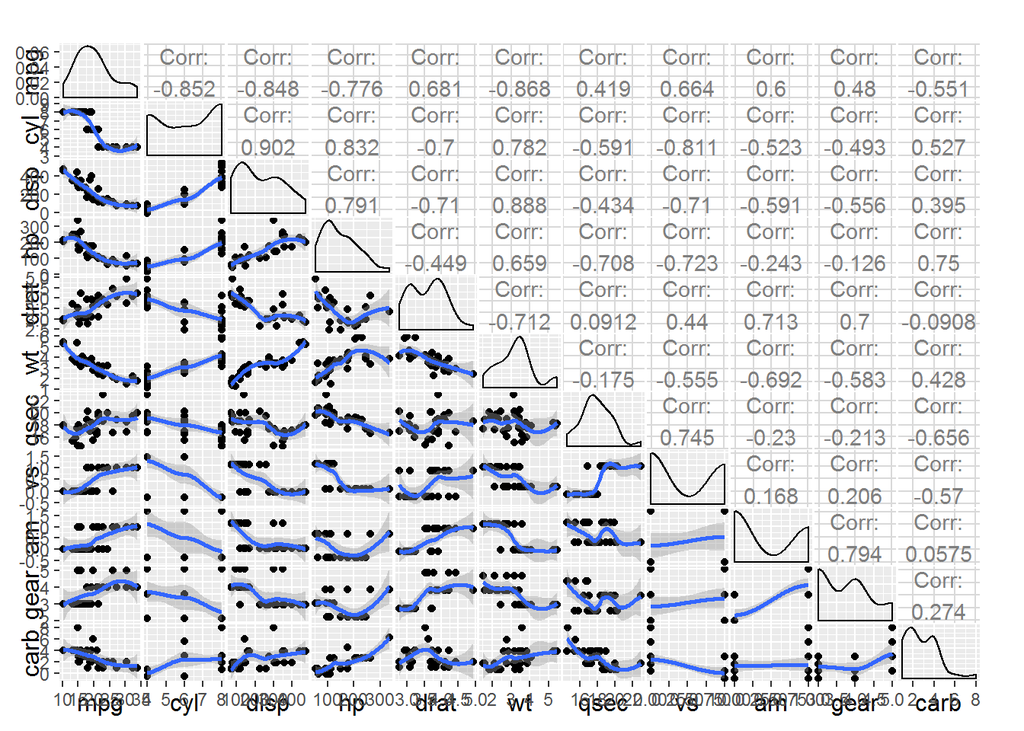

### Linear Regression Model fitting

```
##              Estimate Std. Error   t value     Pr(>|t|)
## (Intercept) 17.147368   1.124603 15.247492 1.133983e-15
## factor(am)1  7.244939   1.764422  4.106127 2.850207e-04
```

**coefficient interpretation** + Estimated mean of `automatic` transmission is 17.147 mpg + Therefore 7.244 is the estimated mean comparing `manual` transmission with `automatic` transmission. And the `am` variable is significant with regression variation 0.3384589 and standard deviation around the regression line is 4.9020288.

#### using full model

- There is no significant variables and the huge standard errors due to that coefficients are inflated. Main reason could be the `collinearity` between the predictor variables.And the regression variation 0.7790215 and standard deviation around the regression line is 2.8331687.

#### Residual Diagnostics

- The residual diagnostics help to identify whether the model is good fit or poor fit.
- In the residual vs fitted there is a systamatic pattern in the residual
- In the qqplot there is a huge deviation from the diagonal in the upper part.
- There is a outlier presence in the 28 and 29 th observation.
- There is both combination of outlier and influence present in 28 and 29 th observation.

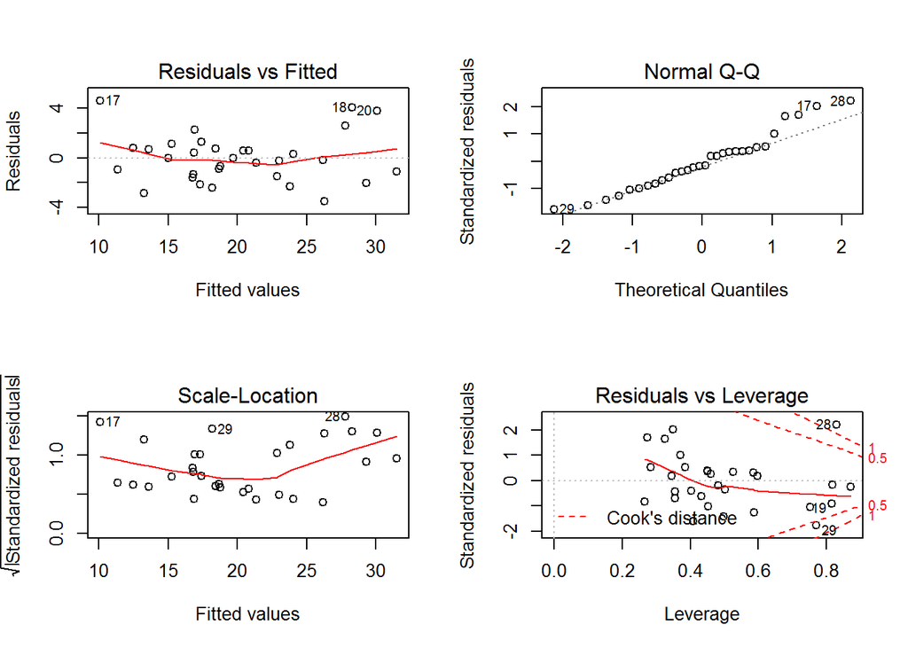

**Evaluating hetroscedasticity**

- There is constant variation present in the residual but in syatamatic pattern ,that causes concern.

```
## Non-constant Variance Score Test
## Variance formula: ~ fitted.values
## Chisquare = 0.6589239    Df = 1     p = 0.4169401
```

### Multiple Model Creation.

#### Variable Selection

##### Multi Collinearity Treatment

- A predictor variable is having linear relationship between 2 or more more variables.
- Variation inflation factor analysesn collinearity among variables
- Greater than 2 considered are severe `Multi-Collinearity`
- Displacement has high collinearity with other variables.

```
##                   GVIF       Df GVIF^(1/(2*Df))
## factor(cyl)  11.319053 1.414214        1.834225
## disp          7.769536 1.000000        2.787389
## hp            5.312210 1.000000        2.304823
## drat          2.609533 1.000000        1.615405
## wt            4.881683 1.000000        2.209453
## qsec          3.284842 1.000000        1.812413
## factor(vs)    2.843970 1.000000        1.686407
## factor(am)    3.151269 1.000000        1.775181
## factor(gear)  7.131081 1.414214        1.634138
## factor(carb) 22.432384 2.236068        1.364858
```

**Removing Variables**

In the process of removing variables such that the collinearity between predictor variables were reduced. In this first step , fitting a model without the displacement variable and Re estimating the vif with newly fitted model indicates `hp` as highest collinear variable.

```
##                   GVIF       Df GVIF^(1/(2*Df))
## factor(cyl)   8.753447 1.414214        1.720065
## hp            5.171339 1.000000        2.274058
## drat          2.609338 1.000000        1.615344
## wt            3.165678 1.000000        1.779235
## qsec          3.255294 1.000000        1.804243
## factor(vs)    2.843720 1.000000        1.686333
## factor(am)    2.966120 1.000000        1.722243
## factor(gear)  6.386305 1.414214        1.589690
## factor(carb) 11.718549 2.236068        1.279050
```

*** Removing variable2**

Similar process followed as like above by removing `hp` variable.The refitted model vif is in control. And the `variable selection` is ready for next modelling.

```
##                  GVIF       Df GVIF^(1/(2*Df))
## factor(cyl)  5.664030 1.414214        1.542700
## drat         2.607671 1.000000        1.614829
## wt           3.154976 1.000000        1.776225
## qsec         3.247714 1.000000        1.802142
## factor(vs)   2.611426 1.000000        1.615991
## factor(am)   2.961625 1.000000        1.720937
## factor(gear) 5.057345 1.414214        1.499618
## factor(carb) 7.120020 2.236068        1.216881
```

#### Automatic Model Selection.

- Stepwise regression is used for automatic variable selection .
- It includes both dackward and forward selection.
- Non significant variables are thrown from the model
- Due to the problem of step wise regression unability to handle Multi collinearity , treated multi-collinearity in the last step.

```
##              Estimate Std. Error   t value     Pr(>|t|)
## (Intercept)  9.617781  6.9595930  1.381946 1.779152e-01
## wt          -3.916504  0.7112016 -5.506882 6.952711e-06
## qsec         1.225886  0.2886696  4.246676 2.161737e-04
## factor(am)1  2.935837  1.4109045  2.080819 4.671551e-02
```

**Non-Significant Variable**

The following variables are thrown from model selection as the fact that they are insignificant.

```
##             Step Df   Deviance Resid. Df Resid. Dev
## 1                                     17   150.2867
## 2 - factor(carb)  5 8.57669369        22   158.8634
## 3 - factor(gear)  2 0.27420055        24   159.1376
## 4  - factor(cyl)  2 8.69024849        26   167.8278
## 5   - factor(vs)  1 0.05849743        27   167.8863
## 6         - drat  1 1.39961796        28   169.2859
```

#### The Final Model

**coefficient interpretation** + We estimate an expected 3.91 mpg decrease in Miles for every 1000lb increase in weight , holding other variables constant. + we estimate an expected 1.22 mpg increase in Miles for every increase in quarter mile time, holding other variables constant. + The increase in mpg estimated is 2.93 when comparing `manual` transmission with `automatic` transmission at the mean weight and qsec.

```
##              Estimate Std. Error   t value     Pr(>|t|)
## (Intercept)  9.617781  6.9595930  1.381946 1.779152e-01
## mtcars$wt   -3.916504  0.7112016 -5.506882 6.952711e-06
## mtcars$qsec  1.225886  0.2886696  4.246676 2.161737e-04
## mtcars$am    2.935837  1.4109045  2.080819 4.671551e-02
```

# 3 Strategy for model selection

Thus inclusion of `weight` and `qsec` increases the variance of the `mpg` effect by 64% while further interaction with weight and transmission causes a 78% increase.

```
## [1] 0.6457578 0.7882828
```

**Model Selection**

```
## Analysis of Variance Table
##
## Model 1: mpg ~ factor(am)
## Model 2: mpg ~ wt + qsec + factor(am)
## Model 3: mpg ~ wt + qsec + factor(am) + wt:factor(am)
##   Res.Df    RSS Df Sum of Sq      F    Pr(>F)
## 1     30 720.90
## 2     28 169.29  2    551.61 63.497 6.195e-11 ***
## 3     27 117.28  1     52.01 11.974  0.001809 **
## ---
## Signif. codes:  0 '***' 0.001 '**' 0.01 '*' 0.05 '.' 0.1 ' ' 1
```

### Conclusion

From the above analysis the manual transmission is better than automatic transmission .And the MPG difference between the manual and automatic transmission is 2.93 at the mean weight and qsec.